# Living Updates from The Living SEB Skills Project

Authors

Affiliation

Tommaso Feraco

University of Padova

Margherita Calderan

University of Padova

Gerardo Pellegrino

University of Padova

## Document and Data info

**Document last update:** 2026-10-13

**Data last updated:** 2026-10-13

**Latest release:** data-update-26-09

**Living SEB app:** available [here](https://feracotommaso.github.io/living_SEB_review/shiny-app.html)

## Project overview

The *Living SEB Skills Project* is an ongoing initiative aimed at building a transparent, cumulative, and continuously updated resource for the study of **social, emotional, and behavioral (SEB) skills** (Soto, Napolitano, and Roberts 2021). Within this framework, SEB skills are organized into five broad domains: Self-management skills, which concern the capacity to plan, persist, and complete goal-directed tasks; Innovation skills, which reflect the ability to engage with new ideas and think creatively; Social engagement skills, which involve efficiently communicating and participating in social interactions; Cooperation skills, which support positive and constructive relationships with others; and Emotional resilience skills, which refer to the capacity to regulate emotions and cope effectively with stress and difficulties. Together, these domains provide an integrative way of studying skills that are often discussed under labels such as soft skills, social-emotional skills, or 21st-century skills.

The main goal of the *Living SEB Skills Project* is to make research in this area easier to monitor, synthesize, and use by maintaining a database that is updated regularly and organized so that new evidence can be incorporated over time. This makes it possible to track the development of the field, reduce fragmentation, and support a more cumulative and reproducible approach to research synthesis.

This monthly report is part of that broader effort. Its purpose is to provide an updated overview of the current state of the database and to summarize some of the main results that may emerge from the most recent release. Because the project follows a living approach, the contents of the database may expand over time as new studies become available and are screened, coded, and added to the resource. For this reason, the results reported here should be interpreted as the most up-to-date picture currently available rather than as a final or definitive summary of the literature.

The sections that follow first describe the data currently included in the project and then present selected results obtained from the latest version of the database.

# The Database

At the time of writing, the systematic search identified 571 publications (Scopus = 349; WOS = 222). After removing duplicates, screening titles and abstracts, and reviewing full texts, 47 studies were retained for the living review and 29 studies met criteria for quantitative synthesis. These include a total of 37 independent samples (see Figure 1), with sample sizes ranging from 123 to 5075 (median = 525).

Across these studies, a total of 20753 correlation coefficients were coded, representing 6551 unique pairwise associations. Of these, 17054 correlations (4168 unique associations) involved at least one SEB domain or facet measured with a BESSI instrument.

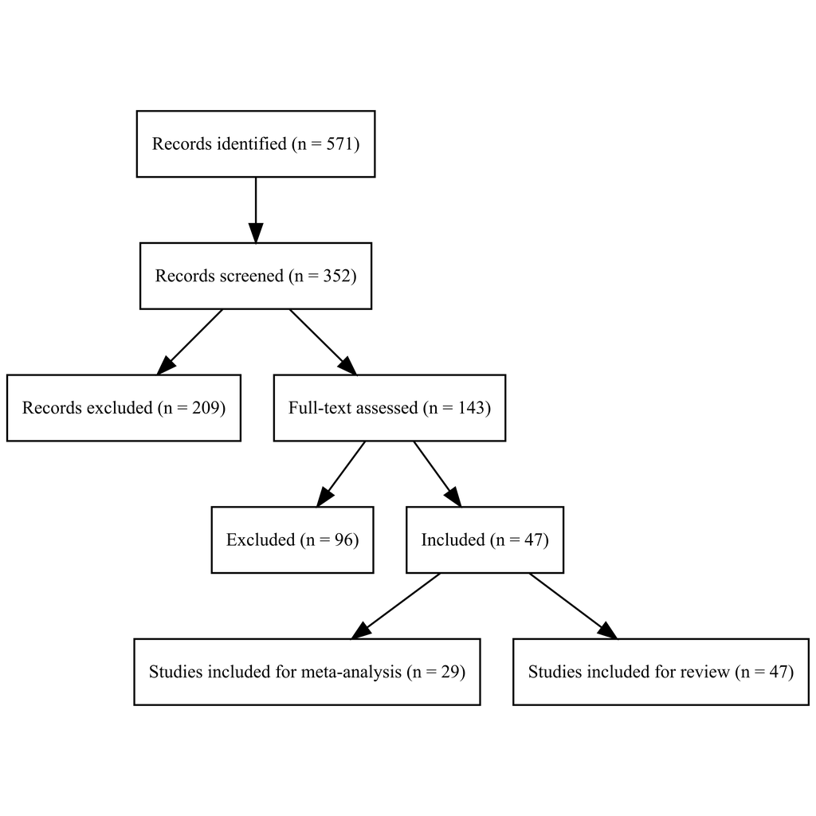

Figure 1: PRISMA flow chart

# Gender Differences

Using the correlations available, it is possible to gauge information also on group differences. To do so, we use a three-level random-effects model.

Because gender was coded 0 = male and 1 = female, positive correlations indicate higher scores among females, whereas negative correlations indicate higher scores among males.

A total of 248 effect sizes from 23 studies and 31 samples were included. For each SEB domain, the median available sample size was 525 (minimum sample size = 123; maximum sample size = 5075).

The full set of results is available in Table 1 and Figure 2.

Table 1: Meta-analytical associations between SEB skills and Biological Sex

| Skill | N (k) | r | CI | PI | se | q | tau2 |
| --- | --- | --- | --- | --- | --- | --- | --- |
| Cooperation | 26310 (30) | 0.04** | 0.01; 0.07 | -0.10; 0.18 | 0.01 | 151 (29)* | 0.00 |
| Emotional resilience | 26266 (30) | -0.19*** | -0.25; -0.13 | -0.46; 0.11 | 0.03 | 335 (29)* | 0.02 |
| Innovation | 25914 (28) | 0.01 | -0.03; 0.05 | -0.16; 0.18 | 0.02 | 224 (27)* | 0.01 |
| Self-management | 26236 (29) | 0.03 | 0.00; 0.06 | -0.11; 0.17 | 0.02 | 193 (28)* | 0.00 |
| Social engagement | 26051 (29) | -0.06** | -0.10; -0.02 | -0.22; 0.10 | 0.02 | 151 (28)* | 0.01 |

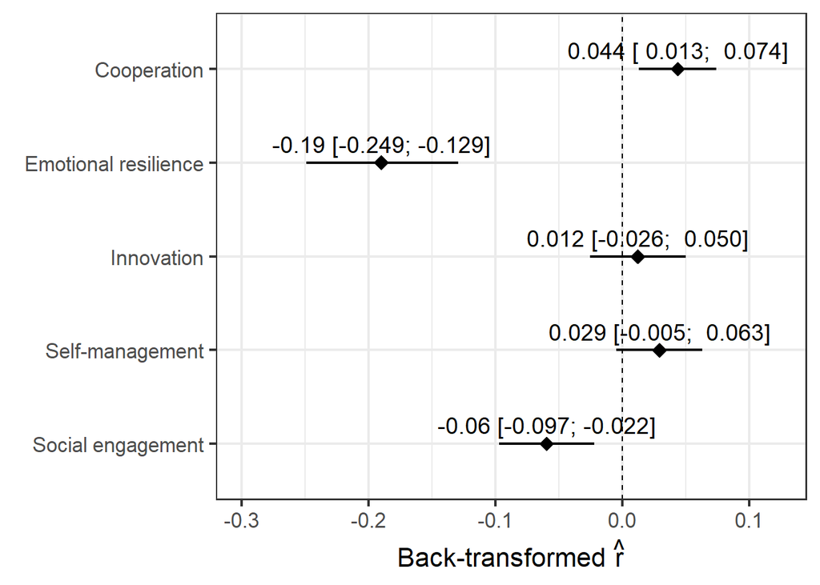

Figure 2: Meta-analytical associations between the five SEB domains and Biological Sex.

Of the five meta-analysed correlations with biological sex, one were larger than |0.10|, with significant effects (p < 0.01) ranging between -0.19 (i.e., Emotional resilience) and 0.04 (i.e., Cooperation).

# SEB Skills and Academic Achievement

Onother interesting question we may tackle using the *Living SEB Skills Project*’s database, is **whether SEB skills are important for academic achievement**.

We try to answer this question at three different levels:

- Are SEB skills singularly associated with academic achievement?
- Do SEB skills predict academic achievement beyond the Big Five?
- Does any specific skill show incremental validity beyond the other skills?

## The Association Between SEB Skills and Academic Achievement

To test the bivariate associations between the five SEB skill domains and academic achievement, we use a three-level random-effects model.

A total of 130 effect sizes from 12 studies and 13 samples were included. For each SEB domain, the median available sample size was 598 (minimum sample size = 150; maximum sample size = 5075).

The full set of results is available in Table 2 and Figure 3.

Table 2: Meta-analytical associations between SEB skills and academic achievement

| Skill | N (k) | r | CI | PI | se | q | tau2 |
| --- | --- | --- | --- | --- | --- | --- | --- |
| Cooperation | 13945 (13) | 0.11** | 0.05; 0.17 | -0.08; 0.29 | 0.03 | 62 (12)* | 0.01 |
| Emotional resilience | 13945 (13) | 0.08** | 0.03; 0.13 | -0.08; 0.23 | 0.02 | 39 (12)* | 0.00 |
| Innovation | 13945 (13) | 0.14** | 0.07; 0.21 | -0.11; 0.37 | 0.03 | 112 (12)* | 0.01 |
| Self-management | 13945 (13) | 0.24*** | 0.19; 0.29 | 0.07; 0.40 | 0.02 | 64 (12)* | 0.01 |
| Social engagement | 13945 (13) | 0.12*** | 0.06; 0.17 | -0.06; 0.29 | 0.02 | 49 (12)* | 0.01 |

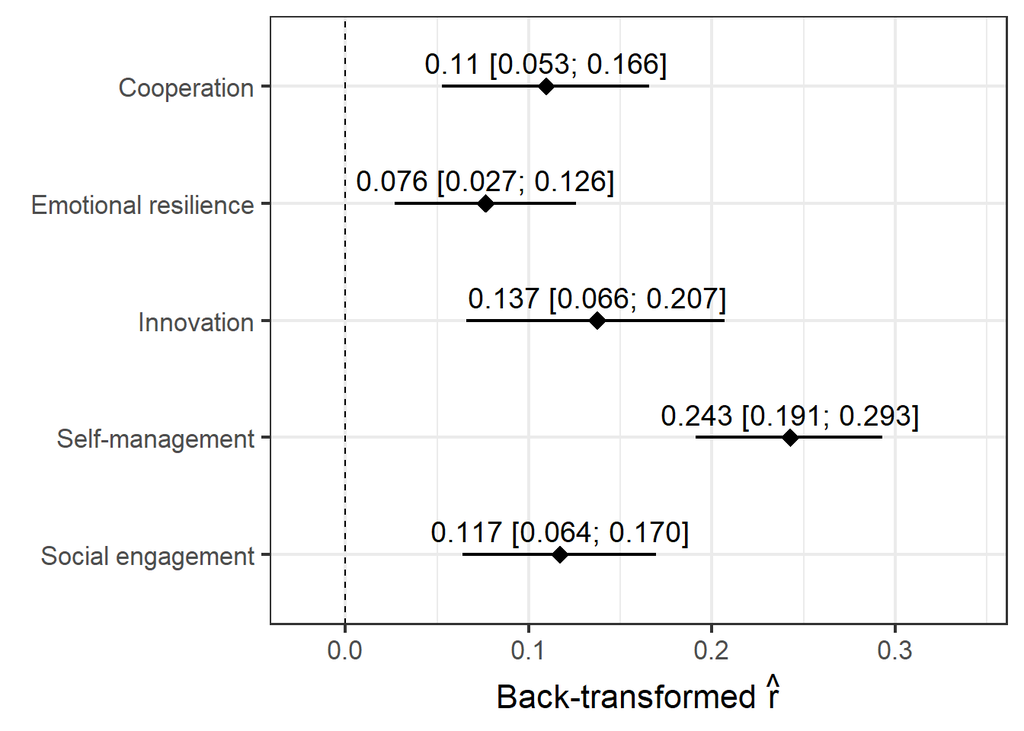

Figure 3: Meta-analytical associations between the five SEB domains and academic achievement.

Of the five meta-analysed correlations with academic achievement, four were larger than 0.10, with significant effects (p < 0.01) ranging between 0.08 (i.e., Emotional resilience) and 0.24 (i.e., Self-management).

## SEB Skills or Big Five Traits?

Using one-stage meta-analytic structural equation modelling (OSMASEM) procedures (Jak and Cheung 2020), five saturated regression models were estimated, each including one SEB domain and its matched Big Five trait as predictors of academic achievement.

MASEM analyses were based on varying number of effect sizes per pairwise correlation (i.e., different correlation matrices), with the minimum available effects per correlation being 4 and the maximum being 32. As a consequence, also sample sizes and precision differed, with the minimum being 3310 (i.e., correlations between personality traits and academic achievement) and the maximum being 27552 (i.e., correlations between SEB domains). Correlation matrices were taken from 34 samples included in 26 different studies.

Given the low number of studies available for some variables, we set between-study variance to zero and estimated a common effect across studies. This approach avoids attempting to estimate random‐effects components that would be unstable or poorly identified in sparse conditions.

Table 3: OSMASEM regression and correlation coefficients for the five models

| Outcome |  | Predictor | Estimate | se | CI | z |
| --- | --- | --- | --- | --- | --- | --- |
| Academic achievement | ~ | BF Openness | -0.077*** | 0.02 | [-0.12; -0.03] | -3.35 |
| Academic achievement | ~ | Innovation | 0.182*** | 0.02 | [0.15; 0.22] | 10.38 |
| BF Openness | ~~ | Innovation | 0.673*** | 0.01 | [0.66; 0.68] | 117.68 |
| Academic achievement | ~ | BF Conscientiousness | 0.147*** | 0.02 | [0.1; 0.19] | 6.28 |
| Academic achievement | ~ | Self-management | 0.159*** | 0.02 | [0.12; 0.19] | 8.79 |
| Self-management | ~~ | BF Conscientiousness | 0.694*** | 0.00 | [0.68; 0.7] | 127.33 |
| Academic achievement | ~ | BF Extraversion | -0.055* | 0.02 | [-0.1; -0.01] | -2.27 |
| Academic achievement | ~ | Social engagement | 0.147*** | 0.02 | [0.11; 0.18] | 7.65 |
| Social engagement | ~~ | BF Extraversion | 0.71*** | 0.00 | [0.7; 0.72] | 137.90 |
| Academic achievement | ~ | BF Agreeableness | 0.044* | 0.02 | [0; 0.09] | 2.05 |
| Academic achievement | ~ | Cooperation | 0.07*** | 0.01 | [0.04; 0.1] | 4.66 |
| Cooperation | ~~ | BF Agreeableness | 0.584*** | 0.01 | [0.57; 0.6] | 86.31 |
| Academic achievement | ~ | BF Neuroticism | 0.06* | 0.02 | [0.01; 0.11] | 2.54 |
| Academic achievement | ~ | Emotional resilience | 0.093*** | 0.02 | [0.06; 0.13] | 5.07 |
| BF Neuroticism | ~~ | Emotional resilience | -0.688*** | 0.00 | [-0.7; -0.68] | -130.14 |

## The Golden Skill for Academic Achievement

To test whether any specific SEB skill shows incremental predictive validity for academic achievement beyond all other skills we performed an additional one-stage meta-analytic structural equation modelling (OSMASEM) estimating one multiple regression model including all SEB domains as predictors of academic achievement.

Table 4: OSMASEM regression coefficients for the multiple regression model including all five skill domains

| Outcome |  | Predictor | Estimate | se | CI | z |
| --- | --- | --- | --- | --- | --- | --- |
| Academic achievement | ~ | Cooperation | -0.057*** | 0.01 | [-0.07; -0.04] | -7.00 |
| Academic achievement | ~ | Emotional resilience | -0.108*** | 0.01 | [-0.12; -0.09] | -13.26 |
| Academic achievement | ~ | Innovation | 0.024** | 0.01 | [0.01; 0.04] | 3.02 |
| Academic achievement | ~ | Self-management | 0.231*** | 0.01 | [0.22; 0.25] | 29.41 |
| Academic achievement | ~ | Social engagement | -0.015 | 0.01 | [-0.03; 0] | -1.84 |

From Table 4, two of the SEB skills showed significant associations (*p* < 0.01) larger than |0.1| with academic achievement beyond the other skill domains. Specifically, Emotional resilience (b = -0.11; 95% CI [-0.12; -0.09]; p < 0.001), Self-management (b = 0.23; 95% CI [0.22; 0.25]; p < 0.001) showed significant and practically meaningful associations with academic achievement, while all other associations were lower than |0.06| and/or non-significant.

# Methods

All methods, including preregistration, transparency, data gathering procedures, and coding information are reported in the main article.

## Analyses

When referring to three-level random-effects model, we nested effects within samples and studies. In line with Borenstein and colleagues (2021), Fisher’s *z* transformations were applied and then back-transformed to Pearson’s *r* for interpretation. The metafor package was used for these analyses (Viechtbauer 2010).

On the other hand, OSMASEM models were used to estimate the structural models of interest in a single step by fitting a structural equation model directly to the meta-analytic covariance structure while simultaneously modeling sampling variance and between-study heterogeneity. This approach allows regression paths to be estimated within an SEM framework using the full pooled covariance matrix. The metaSEM (Cheung 2024) and lavaan (Rosseel 2012) R packages were used for these analysis.

# Reproducibility via the Living SEB App

All analyses can be reproduced in the Meta-analysis and MetaSEM modules of the [*Living SEB App*](https://feracotommaso.github.io/living_SEB_review/shiny-app.html). Users can select specific subsets of studies, download data and R code, and generate updated reports.

# References

Borenstein, Michael, Larry V. Hedges, Julian P. T. Higgins, and Hannah R. Rothstein. 2021. *Introduction to Meta-Analysis*. John Wiley & Sons.

Cheung, Mike W.-L. 2024. *metaSEM: Meta-Analysis Using Structural Equation Modeling*. https://cran.r-project.org/web/packages/metaSEM/index.html.

Jak, Suzanne, and Mike W. -L. Cheung. 2020. “Meta-Analytic Structural Equation Modeling with Moderating Effects on SEM Parameters.” *Psychological Methods* 25 (4): 430–55. https://doi.org/10.1037/met0000245.

Rosseel, Yves. 2012. “Lavaan: An R Package for Structural Equation Modeling and More Version 0.5-12 (BETA),” 37.

Soto, Christopher J., Christopher M. Napolitano, and Brent W. Roberts. 2021. “Taking Skills Seriously: Toward an Integrative Model and Agenda for Social, Emotional, and Behavioral Skills.” *Current Directions in Psychological Science* 30 (1): 26–33. https://doi.org/10.1177/0963721420978613.

Viechtbauer, Wolfgang. 2010. “Conducting meta-analyses in R with the metafor package.” *Journal of Statistical Software* 36 (3): 1–48. https://doi.org/10.18637/jss.v036.i03.